# Exploratory Data analysis

```python
import pandas as pd
import numpy as np
import matplotlib.pyplot as plt
import seaborn as sns
```

```python
df = pd.read_csv('train.csv')
```

```python
df.head()
```

|  | PassengerId | Survived | Pclass | Name | Sex | Age | SibSp | Parch | Ticket | Fare | Cabin | Embarked |
| --- | --- | --- | --- | --- | --- | --- | --- | --- | --- | --- | --- | --- |
| 0 | 1 | 0 | 3 | Braund, Mr. Owen Harris | male | 22.0 | 1 | 0 | A/5 21171 | 7.2500 | NaN | S |
| 1 | 2 | 1 | 1 | Cumings, Mrs. John Bradley (Florence Briggs Th... | female | 38.0 | 1 | 0 | PC 17599 | 71.2833 | C85 | C |
| 2 | 3 | 1 | 3 | Heikkinen, Miss. Laina | female | 26.0 | 0 | 0 | STON/O2. 3101282 | 7.9250 | NaN | S |
| 3 | 4 | 1 | 1 | Futrelle, Mrs. Jacques Heath (Lily May Peel) | female | 35.0 | 1 | 0 | 113803 | 53.1000 | C123 | S |
| 4 | 5 | 0 | 3 | Allen, Mr. William Henry | male | 35.0 | 0 | 0 | 373450 | 8.0500 | NaN | S |

```python
df.shape
```

```
(891, 12)
```

```python
df.columns.values
```

```
array(['PassengerId', 'Survived', 'Pclass', 'Name', 'Sex', 'Age', 'SibSp',
       'Parch', 'Ticket', 'Fare', 'Cabin', 'Embarked'], dtype=object)
```

## Categorical Columns

- Survived
- PClass
- Sex
- Sibsp
- Parch
- Embarked

## Numerical columns

- Age
- Fare
- PassengerId

## Mixed Columns

- Name
- Ticket
- Cabin

```python
df.info()
```

```
<class 'pandas.core.frame.DataFrame'>
RangeIndex: 891 entries, 0 to 890
Data columns (total 12 columns):
 #   Column       Non-Null Count  Dtype
---  ------       --------------  -----
 0   PassengerId  891 non-null    int64
 1   Survived     891 non-null    int64
 2   Pclass       891 non-null    int64
 3   Name         891 non-null    object
 4   Sex          891 non-null    object
 5   Age          714 non-null    float64
 6   SibSp        891 non-null    int64
 7   Parch        891 non-null    int64
 8   Ticket       891 non-null    object
 9   Fare         891 non-null    float64
 10  Cabin        204 non-null    object
 11  Embarked     889 non-null    object
dtypes: float64(2), int64(5), object(5)
memory usage: 83.7+ KB
```

```python
df.isnull().sum()
```

```
PassengerId      0
Survived         0
Pclass           0
Name             0
Sex              0
Age            177
SibSp            0
Parch            0
Ticket           0
Fare             0
Cabin          687
Embarked         2
dtype: int64
```

```python
# Few Conclusions

# 1. Missing value in age, Cabin and embarked columns
# 2. MOre than 70 Percent values are missing in cabin columns, will have to drop
# 3. Few columns have inappropriate data type.
```

```python
## Droping cabin column

df.drop(columns = ['Cabin'], inplace= True)
```

```python
df
```

|  | PassengerId | Survived | Pclass | Name | Sex | Age | SibSp | Parch | Ticket | Fare | Embarked |
| --- | --- | --- | --- | --- | --- | --- | --- | --- | --- | --- | --- |
| 0 | 1 | 0 | 3 | Braund, Mr. Owen Harris | male | 22.0 | 1 | 0 | A/5 21171 | 7.2500 | S |
| 1 | 2 | 1 | 1 | Cumings, Mrs. John Bradley (Florence Briggs Th... | female | 38.0 | 1 | 0 | PC 17599 | 71.2833 | C |
| 2 | 3 | 1 | 3 | Heikkinen, Miss. Laina | female | 26.0 | 0 | 0 | STON/O2. 3101282 | 7.9250 | S |
| 3 | 4 | 1 | 1 | Futrelle, Mrs. Jacques Heath (Lily May Peel) | female | 35.0 | 1 | 0 | 113803 | 53.1000 | S |
| 4 | 5 | 0 | 3 | Allen, Mr. William Henry | male | 35.0 | 0 | 0 | 373450 | 8.0500 | S |
| ... | ... | ... | ... | ... | ... | ... | ... | ... | ... | ... | ... |
| 886 | 887 | 0 | 2 | Montvila, Rev. Juozas | male | 27.0 | 0 | 0 | 211536 | 13.0000 | S |
| 887 | 888 | 1 | 1 | Graham, Miss. Margaret Edith | female | 19.0 | 0 | 0 | 112053 | 30.0000 | S |
| 888 | 889 | 0 | 3 | Johnston, Miss. Catherine Helen "Carrie" | female | NaN | 1 | 2 | W./C. 6607 | 23.4500 | S |
| 889 | 890 | 1 | 1 | Behr, Mr. Karl Howell | male | 26.0 | 0 | 0 | 111369 | 30.0000 | C |
| 890 | 891 | 0 | 3 | Dooley, Mr. Patrick | male | 32.0 | 0 | 0 | 370376 | 7.7500 | Q |

891 rows × 11 columns

```python
# Imputing missing value for age
# startagy - mean

df['Age'].fillna(df['Age'].mean(), inplace = True)
```

```python
# Imputing missing value for embarked

# finding the most appeared value in embarked column

df['Embarked'].value_counts()

# As s is most appeared in emarked column so we will replace missing value with s

df['Embarked'].fillna('S', inplace=True)
```

```python
# Now we are checking is there any null value still remains in the dataset

df.isnull().sum()
```

```
PassengerId    0
Survived       0
Pclass         0
Name           0
Sex            0
Age            0
SibSp          0
Parch          0
Ticket         0
Fare           0
Embarked       0
dtype: int64
```

```python
# want to check one more thing

# Should i check the sibsp and parch to categories

df['SibSp'].value_counts()
```

```
0    608
1    209
2     28
4     18
3     16
8      7
5      5
Name: SibSp, dtype: int64
```

```python
df['Parch'].value_counts()
```

```
0    678
1    118
2     80
5      5
3      5
4      4
6      1
Name: Parch, dtype: int64
```

## Changing the columsn for following columns

- survived(category)
- PClass(category)
- Sex(category)
- Age(int)
- Embarked(category)

```python
df['Survived'] = df['Survived'].astype('category')
df['Pclass'] = df['Pclass'].astype('category')
df['Sex'] = df['Sex'].astype('category')
df['Age'] = df['Age'].astype('int')
df['Embarked'] = df['Embarked'].astype('category')
```

```python
df.info()
```

```
<class 'pandas.core.frame.DataFrame'>
RangeIndex: 891 entries, 0 to 890
Data columns (total 11 columns):
 #   Column       Non-Null Count  Dtype
---  ------       --------------  -----
 0   PassengerId  891 non-null    int64
 1   Survived     891 non-null    category
 2   Pclass       891 non-null    category
 3   Name         891 non-null    object
 4   Sex          891 non-null    category
 5   Age          891 non-null    int32
 6   SibSp        891 non-null    int64
 7   Parch        891 non-null    int64
 8   Ticket       891 non-null    object
 9   Fare         891 non-null    float64
 10  Embarked     891 non-null    category
dtypes: category(4), float64(1), int32(1), int64(3), object(2)
memory usage: 49.4+ KB
```

```python
# five point summry using describe method

df.describe()
```

|  | PassengerId | Age | SibSp | Parch | Fare |
| --- | --- | --- | --- | --- | --- |
| count | 891.000000 | 891.000000 | 891.000000 | 891.000000 | 891.000000 |
| mean | 446.000000 | 29.544332 | 0.523008 | 0.381594 | 32.204208 |
| std | 257.353842 | 13.013778 | 1.102743 | 0.806057 | 49.693429 |
| min | 1.000000 | 0.000000 | 0.000000 | 0.000000 | 0.000000 |
| 25% | 223.500000 | 22.000000 | 0.000000 | 0.000000 | 7.910400 |
| 50% | 446.000000 | 29.000000 | 0.000000 | 0.000000 | 14.454200 |
| 75% | 668.500000 | 35.000000 | 1.000000 | 0.000000 | 31.000000 |
| max | 891.000000 | 80.000000 | 8.000000 | 6.000000 | 512.329200 |

```
Out of 891 62% people died in the accident
```

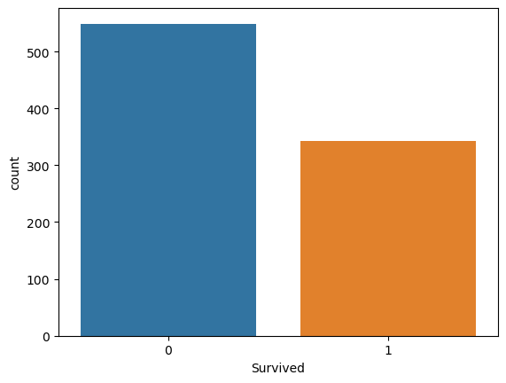

```python
# unvarient analysis

# Let's start with survived column

sns.countplot(df['Survived'])

death_percent = round((df['Survived'].value_counts().values[0]/891)*100)

print('Out of 891 {}% people died in the accident'.format(death_percent))
```

```
3    55.106622
1    24.242424
2    20.650954
Name: Pclass, dtype: float64
```

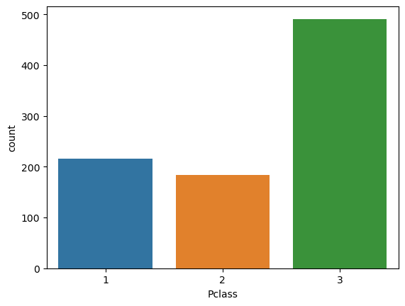

```python
# Pclass column

print((df['Pclass'].value_counts()/891)*100)

sns.countplot(df['Pclass'])

# conclusion : Pclass 3 was the crowded class
```

```
male      64.758698
female    35.241302
Name: Sex, dtype: float64
```

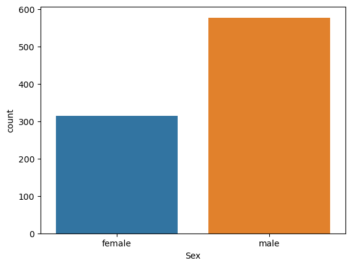

```python
# Sex column

print((df['Sex'].value_counts()/891)*100)

sns.countplot(df['Sex'])
```

```
0    68.237935
1    23.456790
2     3.142536
4     2.020202
3     1.795735
8     0.785634
5     0.561167
Name: SibSp, dtype: float64
```

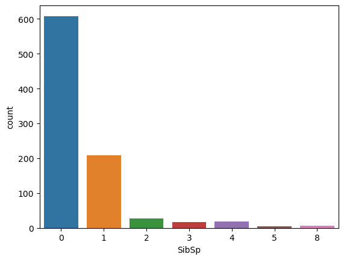

```python
# Sibsp column

print((df['SibSp'].value_counts()/891)*100)

sns.countplot(df['SibSp'])
```

```
0    76.094276
1    13.243547
2     8.978676
5     0.561167
3     0.561167
4     0.448934
6     0.112233
Name: Parch, dtype: float64
```

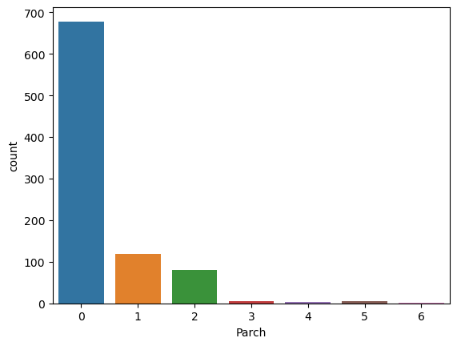

```python
# Parch column

print((df['Parch'].value_counts()/891)*100)

sns.countplot(df['Parch'])
```

```
S    72.502806
C    18.855219
Q     8.641975
Name: Embarked, dtype: float64
```

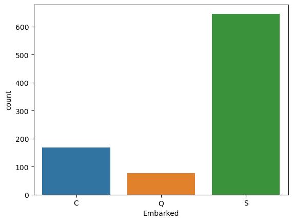

```python
# Embarked column

print((df['Embarked'].value_counts()/891)*100)

sns.countplot(df['Embarked'])
```

```
0.45956263424701577
0.9865867453652877
```

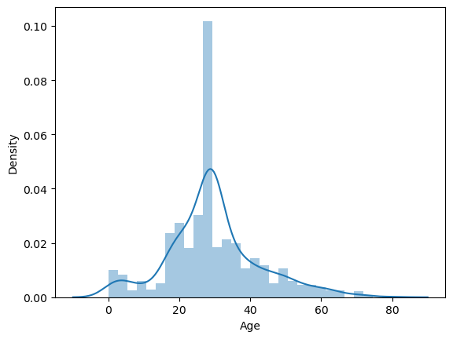

```python
# Age column

sns.distplot(df['Age'])

print(df['Age'].skew())

print(df['Age'].kurt())
```

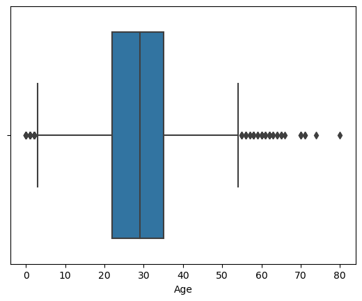

```python
sns.boxplot(df['Age'])
```

```python
# Just out of curiosity

print('people with age in betweeen 60 and 70 are',df[(df['Age']>60) &  (df['Age']<70)].shape[0])
print('people with age in betweeen 60 and 70 are',df[(df['Age']>=70) &  (df['Age']<=75)].shape[0])
print('people with age in betweeen 60 and 70 are',df[(df['Age']>75)] .shape[0])

print('-' *50)

print('people with age between 0 and 1', df[df['Age']<1].shape[0])
```

```
people with age in betweeen 60 and 70 are 15
people with age in betweeen 60 and 70 are 6
people with age in betweeen 60 and 70 are 1
--------------------------------------------------
people with age between 0 and 1 7
```

## Conclusion

- For all practical purposes age can be considered as normal distribution
- Deeper analysis is require for outlier detection.

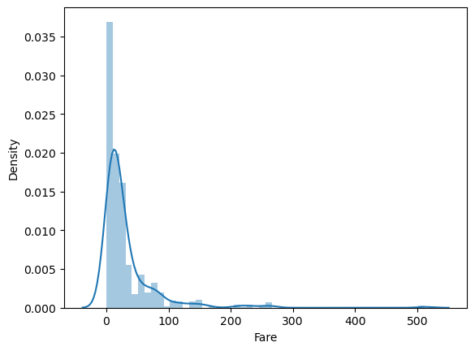

```python
# Fare column

sns.distplot(df['Fare'])
```

```python
print(df['Fare'].skew())
print(df['Fare'].kurt())
```

```
4.787316519674893
33.39814088089868
```

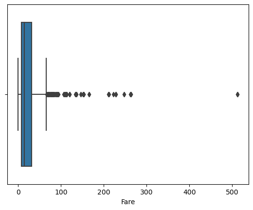

```python
sns.boxplot(df['Fare'])
```

```python
print('people with Fare in between $200 and $300', df[(df['Fare']>200) & (df['Fare']<300)].shape[0] )
print('people with Fare in greater than $300', df[df['Fare']>300].shape[0])
```

```
people with Fare in between $200 and $300 17
people with Fare in greater than $300 3
```

# conclusion

- Highly skewed data, A lot of people had chaper tickets
- Outliers are there in the data

| Survived Pclass | 0 | 1 |
| --- | --- | --- |
| 1 | 37.0 | 63.0 |
| 2 | 52.7 | 47.3 |
| 3 | 75.8 | 24.2 |

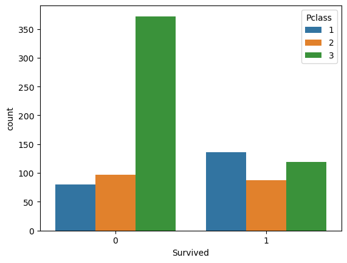

```python
# Multivarient Analysis

# Survival with Pclass

sns.countplot(df['Survived'], hue=df['Pclass'])

pd.crosstab(df['Pclass'], df['Survived']).apply(lambda r: round((r/r.sum())*100,1), axis=1)
```

| Survived Sex | 0 | 1 |
| --- | --- | --- |
| female | 25.8 | 74.2 |
| male | 81.1 | 18.9 |

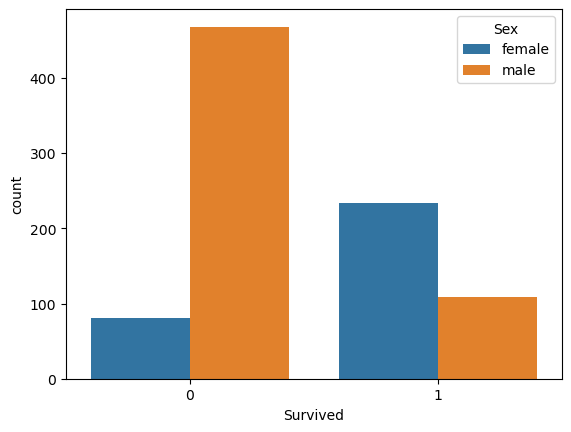

```python
# Survival with Sex

sns.countplot(df['Survived'], hue=df['Sex'])

pd.crosstab(df['Sex'], df['Survived']).apply(lambda r: round((r/r.sum())*100,1), axis=1)
```

| Survived Embarked | 0 | 1 |
| --- | --- | --- |
| C | 44.6 | 55.4 |
| Q | 61.0 | 39.0 |
| S | 66.1 | 33.9 |

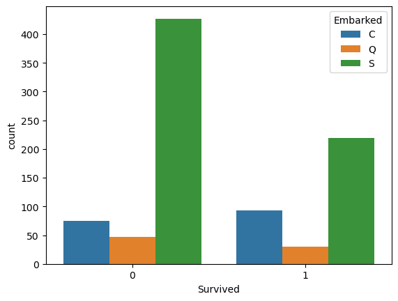

```python
# Survival with Embarked

sns.countplot(df['Survived'], hue=df['Embarked'])

pd.crosstab(df['Embarked'], df['Survived']).apply(lambda r: round((r/r.sum())*100,1), axis=1)
```

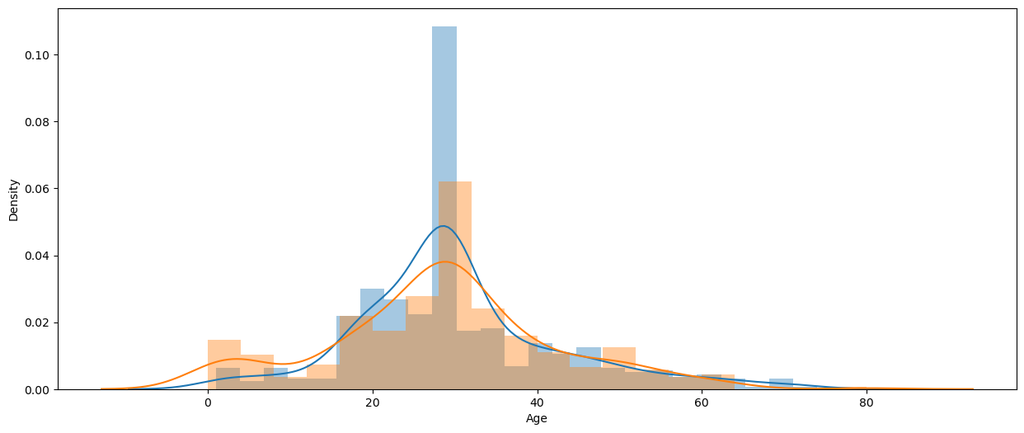

```python
# Survived with Age

plt.figure(figsize = (15,6))
sns.distplot(df[df['Survived']==0]['Age'])
sns.distplot(df[df['Survived']==1]['Age'])
```

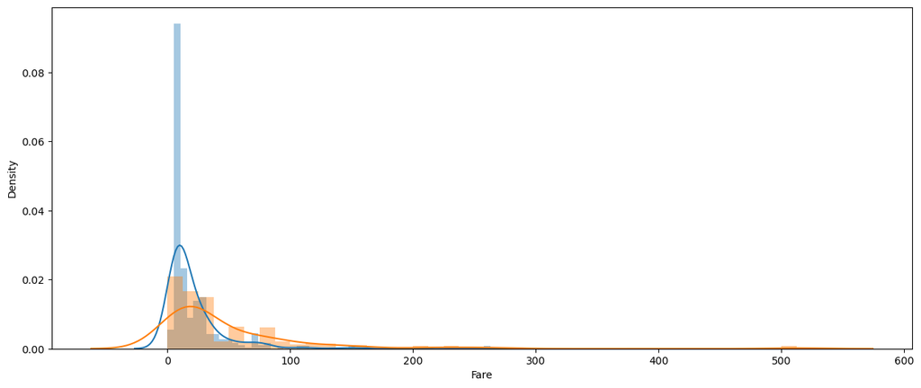

```python
# Survuved with fare

plt.figure(figsize = (15,6))
sns.distplot(df[df['Survived']==0]['Fare'])
sns.distplot(df[df['Survived']==1]['Fare'])
```

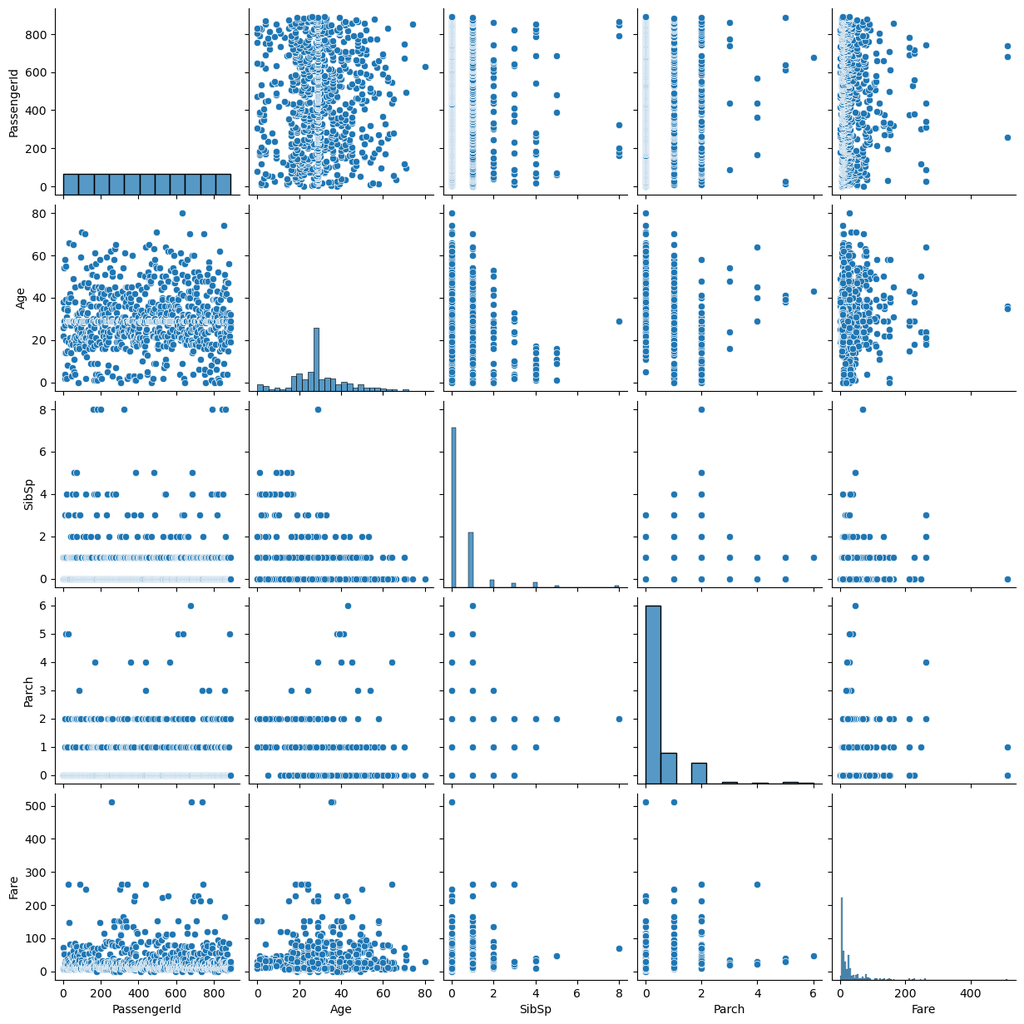

```python
sns.pairplot(df)
```

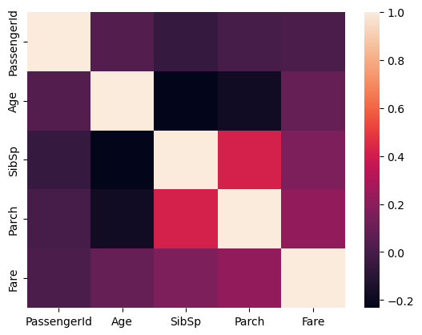

```python
sns.heatmap(df.corr())
```

```python
# Feature engineering

# We will create new column by the name of family which will be sum of sibsp and parh

df['Family_size']=df['SibSp'] + df['Parch']
```

```python
df.head()
```

|  | PassengerId | Survived | Pclass | Name | Sex | Age | SibSp | Parch | Ticket | Fare | Embarked | Family_size |
| --- | --- | --- | --- | --- | --- | --- | --- | --- | --- | --- | --- | --- |
| 0 | 1 | 0 | 3 | Braund, Mr. Owen Harris | male | 22 | 1 | 0 | A/5 21171 | 7.2500 | S | 1 |
| 1 | 2 | 1 | 1 | Cumings, Mrs. John Bradley (Florence Briggs Th... | female | 38 | 1 | 0 | PC 17599 | 71.2833 | C | 1 |
| 2 | 3 | 1 | 3 | Heikkinen, Miss. Laina | female | 26 | 0 | 0 | STON/O2. 3101282 | 7.9250 | S | 0 |
| 3 | 4 | 1 | 1 | Futrelle, Mrs. Jacques Heath (Lily May Peel) | female | 35 | 1 | 0 | 113803 | 53.1000 | S | 1 |
| 4 | 5 | 0 | 3 | Allen, Mr. William Henry | male | 35 | 0 | 0 | 373450 | 8.0500 | S | 0 |

```python
# Now we will engineer a new feature by the name of family type

def Family_type(number):
    if number==0:
        return "Alone"
    elif number>0 and number<=4:
        return "Medium"
    else:
        return "Large"
```

```python
df['Family_type'] = df['Family_size'].apply(Family_type)
```

```python
df.head()
```

|  | PassengerId | Survived | Pclass | Name | Sex | Age | SibSp | Parch | Ticket | Fare | Embarked | Family_size | Family_type |
| --- | --- | --- | --- | --- | --- | --- | --- | --- | --- | --- | --- | --- | --- |
| 0 | 1 | 0 | 3 | Braund, Mr. Owen Harris | male | 22 | 1 | 0 | A/5 21171 | 7.2500 | S | 1 | Medium |
| 1 | 2 | 1 | 1 | Cumings, Mrs. John Bradley (Florence Briggs Th... | female | 38 | 1 | 0 | PC 17599 | 71.2833 | C | 1 | Medium |
| 2 | 3 | 1 | 3 | Heikkinen, Miss. Laina | female | 26 | 0 | 0 | STON/O2. 3101282 | 7.9250 | S | 0 | Alone |
| 3 | 4 | 1 | 1 | Futrelle, Mrs. Jacques Heath (Lily May Peel) | female | 35 | 1 | 0 | 113803 | 53.1000 | S | 1 | Medium |
| 4 | 5 | 0 | 3 | Allen, Mr. William Henry | male | 35 | 0 | 0 | 373450 | 8.0500 | S | 0 | Alone |

```python
df.drop(columns=['SibSp','Parch','Family_size'], inplace = True)
```

```python
df.sample(5)
```

|  | PassengerId | Survived | Pclass | Name | Sex | Age | Ticket | Fare | Embarked | Family_type |
| --- | --- | --- | --- | --- | --- | --- | --- | --- | --- | --- |
| 27 | 28 | 0 | 1 | Fortune, Mr. Charles Alexander | male | 19 | 19950 | 263.000 | S | Large |
| 193 | 194 | 1 | 2 | Navratil, Master. Michel M | male | 3 | 230080 | 26.000 | S | Medium |
| 236 | 237 | 0 | 2 | Hold, Mr. Stephen | male | 44 | 26707 | 26.000 | S | Medium |
| 590 | 591 | 0 | 3 | Rintamaki, Mr. Matti | male | 35 | STON/O 2. 3101273 | 7.125 | S | Alone |
| 708 | 709 | 1 | 1 | Cleaver, Miss. Alice | female | 22 | 113781 | 151.550 | S | Alone |

```python
pd.crosstab(df['Family_type'], df['Survived']).apply(lambda r: round((r/r.sum())*100,1), axis=1)
```

| Survived Family_type | 0 | 1 |
| --- | --- | --- |
| Alone | 69.6 | 30.4 |
| Large | 85.1 | 14.9 |
| Medium | 44.0 | 56.0 |

## Detecting outliers

### Numerical Data

- If data is following normal distribution, anything beyond 3SD -mean +3SD can be considered as outlier.
- If data does not follow normal distribution, using boxplot we can eliminate point beyond Q1 - 1.5|QR and Q3 - 1.5|QR

### Categorical Data

- If the col is highly imbalanced for eg male 10000 and female 2 then we can eliminate female

```python
# Handling outliers in age(Almost normal)

df = df[df['Age']<(df['Age'].mean()+ 3 * df['Age'].std())]
```

```python
df.shape
```

```
(884, 10)
```

```python
# Handling outliers from fair column

# Findind quartiles

q1= np.percentile(df['Fare'], 25)
q3= np.percentile(df['Fare'], 75)

outliers_low=q1 - 1.5 * (q3-q1)
outliers_high = q3 + 1.5 * (q3-q1)

df=df[(df['Fare']>outliers_low) & (df['Fare']<outliers_high)]
```

```python
# One Hot encoding

df.sample(4)

# cols to be tranformed are Pclass, Sex, Embarked, Family_type

df = pd.get_dummies(data = df, columns =['Pclass', 'Sex', 'Embarked', 'Family_type'], drop_first = True,)
```

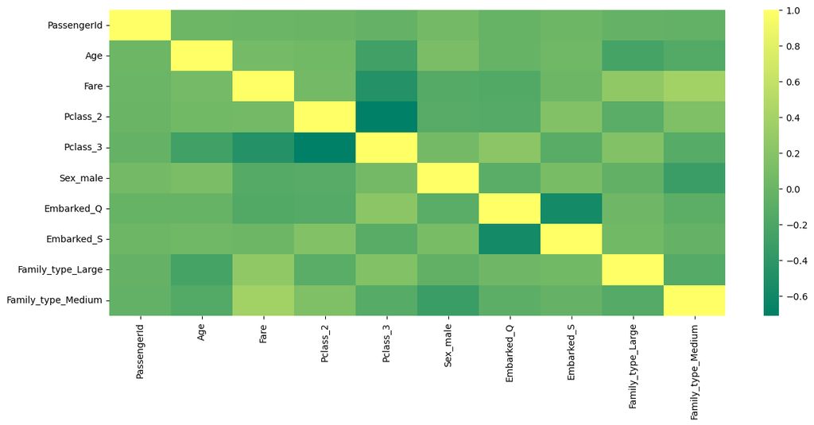

```python
plt.figure(figsize=(15,6))
sns.heatmap(df.corr(), cmap='summer')
```

## Drawing conclusion

- Chance of female survival is higher then male survival.
- Travelling in Pclass 3 was deadliest.
- Somehow, people going to C survived more
- People in age range of 20 to 40 had a higher chance of not surviving.
- people travelling with smaller families had a higher chance of surviving the accident in comparison to people with larger familes and travelling alone.

## Communicating result

- You can write a report/blog etc
- You can give a PPT in front of others
- You can describe the result face to face